# Machine Learning Project

## ** I. Background:**

Using devices such as Jawbone Up, Nike FuelBand, and Fitbit it is now possible to collect a large amount of data about personal activity relatively inexpensively. One thing that people regularly do is quantify how much of a particular activity they do, but they rarely quantify how well they do it. In this project, your goal will be to use data from accelerometers on the belt, forearm, arm, and dumbell of 6 participants. They were asked to perform barbell lifts correctly and incorrectly in 5 different ways

The goal of your project is to predict the manner in which they did the exercise. This is the “classe” variable in the training set. You may use any of the other variables to predict with. You should create a report describing how you built your model, how you used cross validation, what you think the expected out of sample error is, and why you made the choices you did. You will also use your prediction model to predict 20 different test cases.

## ** II. Setting up Environment and Loading Dataset:**

Let’s first load all needed libraries on our working environment:

```r
library(caret)
library(rattle)
library(readr)
```

Now, set the seed for the sake of reproducibility:

```r
set.seed(1234)
```

The project is now ready to load the datasets:

```r
setwd("~/MachineLearning project")
pml_training <- read_csv("pml-training.csv")
pml_testing <- read_csv("pml-testing.csv")
```

Set the *pml_testing* aside for final validation, and we then can partition the *pml_training*into 2 sets to pick the best model using:

```r
inTrain <- createDataPartition(pml_training$classe, p = 0.7, list = FALSE)
training <- pml_training[inTrain,]
testing <- pml_training[-inTrain,]
```

## **III. Processing the Data:**

The first step is to remove the near zero variance variables using the code:

```r
nzv <- nearZeroVar(training, saveMetrics = TRUE)
training <- training[,nzv$nzv==FALSE]
```

you may have noticed that the first columns are for indexing and timestamps; these probably should not be included since they do not have any effect on the outcome:

```r
training <- training[, -(1:5)]
```

Last step is to deal with our missing data; since many of our variables contain 70% or more missing values, so excluding them altogether will make more sense. then we can handle other NAs.

```r
AllNA <- sapply(training, function(x) mean(is.na(x))) > 0.7
training <- training [, AllNA == FALSE]

#calculate if there still are missing values
sum(is.na(training))
```

```
## [1] 3
```

```r
#let's impute those values
training[is.na(training)] <- 0
```

And finally let’s prep our testing set the same way we did to the training, so it’s ready as well:

```r
testing <- testing[, -(1:5)]
AllNA_test <- sapply(testing, function(x) mean(is.na(x))) > 0.7
testing <- testing [, AllNA_test == FALSE]
testing[is.na(testing)] <- 0
```

## **IV.Building Prediction Models:**

Let’s now build different prediction models in order to compare their outcomes and accuracy in prediction. For our purpose here, let’s apply *Decision Tree*, *Random Forests* and *Boosting*:

### IV. A. Predicting with Decision Tree:

```r
set.seed(1234)
model_rpart <- train(classe ~ ., method = "rpart", data = training)
print(model_rpart$finalModel)
```

```
## n= 13737
##
## node), split, n, loss, yval, (yprob)
##       * denotes terminal node
##
##  1) root 13737 9831 A (0.28 0.19 0.17 0.16 0.18)
##    2) roll_belt< 130.5 12563 8667 A (0.31 0.21 0.19 0.18 0.11)
##      4) pitch_forearm< -33.05 1111   14 A (0.99 0.013 0 0 0) *
##      5) pitch_forearm>=-33.05 11452 8653 A (0.24 0.23 0.21 0.2 0.12)
##       10) magnet_dumbbell_y< 436.5 9625 6886 A (0.28 0.18 0.24 0.19 0.11)
##         20) roll_forearm< 123.5 5965 3517 A (0.41 0.18 0.18 0.17 0.059) *
##         21) roll_forearm>=123.5 3660 2435 C (0.08 0.17 0.33 0.23 0.18) *
##       11) magnet_dumbbell_y>=436.5 1827  904 B (0.033 0.51 0.043 0.23 0.19) *
##    3) roll_belt>=130.5 1174   10 E (0.0085 0 0 0 0.99) *
```

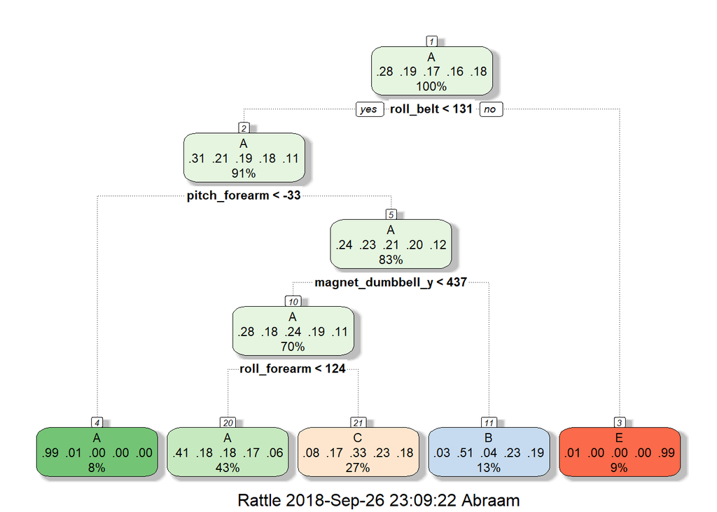

```r
fancyRpartPlot(model_rpart$finalModel)
```

and in order to calculate its accuracy let’s predict on *testing* dataset and create the confusion matrix:

```r
pred_rpart <- predict(model_rpart, newdata = testing)
conf_rpart <- confusionMatrix(pred_rpart, as.factor(testing$classe))
conf_rpart
```

```
## Confusion Matrix and Statistics
##
##           Reference
## Prediction    A    B    C    D    E
##          A 1530  486  493  452  168
##          B   35  379   31  164  145
##          C  105  274  502  348  302
##          D    0    0    0    0    0
##          E    4    0    0    0  467
##
## Overall Statistics
##
##                Accuracy : 0.489
##                  95% CI : (0.4762, 0.5019)
##     No Information Rate : 0.2845
##     P-Value [Acc > NIR] : < 2.2e-16
##
##                   Kappa : 0.3311
##  Mcnemar's Test P-Value : NA
##
## Statistics by Class:
##
##                      Class: A Class: B Class: C Class: D Class: E
## Sensitivity            0.9140   0.3327   0.4893   0.0000  0.43161
## Specificity            0.6203   0.9210   0.7882   1.0000  0.99917
## Pos Pred Value         0.4890   0.5027   0.3279      NaN  0.99151
## Neg Pred Value         0.9478   0.8519   0.8797   0.8362  0.88641
## Prevalence             0.2845   0.1935   0.1743   0.1638  0.18386
## Detection Rate         0.2600   0.0644   0.0853   0.0000  0.07935
## Detection Prevalence   0.5317   0.1281   0.2602   0.0000  0.08003
## Balanced Accuracy      0.7671   0.6269   0.6388   0.5000  0.71539
```

### IV. B. Predicting with Boosting:

```r
set.seed(1234)
#we create the model with number of 3 only to decrease computational time
model_gbm <- train(classe ~ ., data = training, method = "gbm", verbose = FALSE, trControl = trainControl(method = "cv", number = 3))
print(model_gbm$finalModel)
```

```
## A gradient boosted model with multinomial loss function.
## 150 iterations were performed.
## There were 53 predictors of which 42 had non-zero influence.
```

And to evaluate this model:

```r
pred_gbm <- predict(model_gbm, newdata = testing)
conf_gbm <- confusionMatrix(pred_gbm, as.factor(testing$classe))
conf_gbm
```

```
## Confusion Matrix and Statistics
##
##           Reference
## Prediction    A    B    C    D    E
##          A 1673   14    0    0    0
##          B    0 1106    2    8    1
##          C    0   14 1021    8    3
##          D    1    5    2  947    8
##          E    0    0    1    1 1070
##
## Overall Statistics
##
##                Accuracy : 0.9884
##                  95% CI : (0.9854, 0.991)
##     No Information Rate : 0.2845
##     P-Value [Acc > NIR] : < 2.2e-16
##
##                   Kappa : 0.9854
##  Mcnemar's Test P-Value : NA
##
## Statistics by Class:
##
##                      Class: A Class: B Class: C Class: D Class: E
## Sensitivity            0.9994   0.9710   0.9951   0.9824   0.9889
## Specificity            0.9967   0.9977   0.9949   0.9967   0.9996
## Pos Pred Value         0.9917   0.9902   0.9761   0.9834   0.9981
## Neg Pred Value         0.9998   0.9931   0.9990   0.9965   0.9975
## Prevalence             0.2845   0.1935   0.1743   0.1638   0.1839
## Detection Rate         0.2843   0.1879   0.1735   0.1609   0.1818
## Detection Prevalence   0.2867   0.1898   0.1777   0.1636   0.1822
## Balanced Accuracy      0.9980   0.9844   0.9950   0.9896   0.9942
```

### IV. C. Predicting with Random Forests:

```r
set.seed(1234)
#we create the model with number of 3 only to decrease computational time
model_rf <- train(classe ~ ., data = training, method = "rf", trControl = trainControl(method = "cv", number = 3))
print(model_rf$finalModel)
```

```
##
## Call:
##  randomForest(x = x, y = y, mtry = param$mtry)
##                Type of random forest: classification
##                      Number of trees: 500
## No. of variables tried at each split: 27
##
##         OOB estimate of  error rate: 0.23%
## Confusion matrix:
##      A    B    C    D    E  class.error
## A 3904    1    0    0    1 0.0005120328
## B    4 2651    2    1    0 0.0026335591
## C    0    5 2390    1    0 0.0025041736
## D    0    0    6 2245    1 0.0031083481
## E    0    2    0    7 2516 0.0035643564
```

Let’s evaluate it:

```r
pred_rf <- predict(model_rf, newdata = testing)
conf_rf <- confusionMatrix(pred_rf, as.factor(testing$classe))
conf_rf
```

```
## Confusion Matrix and Statistics
##
##           Reference
## Prediction    A    B    C    D    E
##          A 1674    3    0    0    0
##          B    0 1135    4    0    0
##          C    0    1 1022    1    0
##          D    0    0    0  963    2
##          E    0    0    0    0 1080
##
## Overall Statistics
##
##                Accuracy : 0.9981
##                  95% CI : (0.9967, 0.9991)
##     No Information Rate : 0.2845
##     P-Value [Acc > NIR] : < 2.2e-16
##
##                   Kappa : 0.9976
##  Mcnemar's Test P-Value : NA
##
## Statistics by Class:
##
##                      Class: A Class: B Class: C Class: D Class: E
## Sensitivity            1.0000   0.9965   0.9961   0.9990   0.9982
## Specificity            0.9993   0.9992   0.9996   0.9996   1.0000
## Pos Pred Value         0.9982   0.9965   0.9980   0.9979   1.0000
## Neg Pred Value         1.0000   0.9992   0.9992   0.9998   0.9996
## Prevalence             0.2845   0.1935   0.1743   0.1638   0.1839
## Detection Rate         0.2845   0.1929   0.1737   0.1636   0.1835
## Detection Prevalence   0.2850   0.1935   0.1740   0.1640   0.1835
## Balanced Accuracy      0.9996   0.9978   0.9978   0.9993   0.9991
```

## **V. Predicting Results on Test Data:**

```r
pred_test <- predict(model_rf, newdata = pml_testing)
pred_test
```

```
##  [1] B A B A A E D B A A B C B A E E A B B B
## Levels: A B C D E
```